# Session 2 Solutions Master

Team Blue

20 October 2020

# Background

Did the *Been there, done that* section hence **most** of the solutions were mine. Notably, part of the ggplot (using the stat_summary func) was partially not mine, although adapted, and the boxcox procedure was completely new to me.

# Importing relevant libraries

Even if a library is used as a one-off, please add it here.

```r
library(tidyverse) #mandatory
library(pastecs) #for easy descriptive stats
library(ggpubr) #useful for cool plots
library(car) #for levene's test - is there a more parsimonious solution?
library(gridExtra) #for plot with subplots
library(MASS) #boxcox procedure
library(knitr) #for kable
library(moments) #for skewness func
```

# 1. Getting data into R

### Solution 1 for importing data: `tidyverse`

The data are provided in space separate values - weirdly enough - and the colnames are offset by 1 such that the ‘id’ col at the beginning is missing.

```r
data <- read_delim("TheDataSet.csv", " ", col_names = c("id", names(read_delim("TheDataSet.csv", " "))),
                   skip = 1)
```

### Solution 2: using the `read.table` function

```r
data <- read.table("TheDataSet.csv", sep = " ", header = TRUE)
```

**Note**

So, the `read.table` (as well as the `data.frame`) function have a default argument for how to handle character vectors (see [here](https://www.rdocumentation.org/packages/utils/versions/3.6.2/topics/read.table) or `??read.table` in `R`). The argument is `stringsAsFactors` and has a default value as `default.stringsAsFactors()`. This default value (`default.stringsAsFactors()`) is a function that then calls the default `R` options set on your environment (you can see all options if you type `options()`).

To check the value of the `stringsAsFactors` global option, simply type `options("stringsAsFactors")`. If `FALSE` appears, that means that the `read.table` function will output the character vectors as character, not factors. If `stringsAsFactors` is set to `TRUE`, then you will be seeing factors, not characters.

Why this discrepancy between R session in this argument? Apparently there has been a bit of controversy around the issue but after a meeting in 2019 from the R team, it has been decided that this global option will now be deprecated as of R 4.0.0 and above (see [here](https://developer.r-project.org/Blog/public/2020/02/16/stringsasfactors/)). Hence, I would perhaps not rely on this.

Best practice, I guess, is that we define the type of each column when we import data (within whichever function we use) to avoid relying on system-specific variables.

In any case, some people might have different values to that global option, hence the discrepancies above. The `tidyverse` funcs (`read_csv`) and the base `read.csv` func do not seem to suffer from the same problem but let me know if you encounter anything weird.

### Solution 3: using base `read.csv` function.

```r
data <- read.csv("TheDataSet.csv", sep = " ")
```

# 2. Exploring the data

Checking the STRucture of the data.

```r
str(data)
```

```
## 'data.frame':    1554 obs. of  10 variables:
##  $ text   : chr  "b'fish'" "b'winter'" "b'chilly'" "b'sock'" ...
##  $ is_lure: chr  "neutral" "correct" "correct" "neutral" ...
##  $ key    : chr  "a" "l" "l" "a" ...
##  $ yes_key: chr  "l" "l" "l" "l" ...
##  $ rt     : num  3.832 1.263 0.73 0.952 1.185 ...
##  $ group  : int  0 0 0 0 0 0 0 0 0 0 ...
##  $ code   : chr  "cl98xe" "cl98xe" "cl98xe" "cl98xe" ...
##  $ old    : logi  FALSE TRUE TRUE FALSE FALSE FALSE ...
##  $ correct: logi  FALSE TRUE TRUE FALSE FALSE TRUE ...
##  $ success: logi  TRUE TRUE TRUE TRUE TRUE FALSE ...
```

Tricky to guess IVs and Dvs as these are design driven but:

- DVs
  - key
  - yes_key
  - correct
  - success
  - rt
- IVs
  - text
  - is_lure
  - group
  - old

Let’s leave to default column specifications and change as needed.

As I will be using `group` as a grouping variable, let’s mutate it to a factor.

```r
data <- data %>%
  mutate(group = as.factor(group))
```

And let’s now output the descriptive statistics.

First, overall descriptives for `rt`:

```r
knitr::kable(stat.desc(data$rt))
```

|  | x |
| --- | --- |
| nbr.val | 1554.0000000 |
| nbr.null | 0.0000000 |
| nbr.na | 0.0000000 |
| min | 0.1663640 |
| max | 8.0370838 |
| range | 7.8707199 |
| sum | 1943.9663837 |
| median | 1.0042516 |
| mean | 1.2509436 |
| SE.mean | 0.0202967 |
| CI.mean.0.95 | 0.0398117 |
| var | 0.6401767 |
| std.dev | 0.8001104 |
| coef.var | 0.6396055 |

Descriptive stats by `group` (levels = 0/1):

```r
knitr::kable(unlist(by(data$rt, data$group, stat.desc))) #maybe split column and prettify
```

|  | x |
| --- | --- |
| 0.nbr.val | 703.0000000 |
| 0.nbr.null | 0.0000000 |
| 0.nbr.na | 0.0000000 |
| 0.min | 0.1663640 |
| 0.max | 8.0370838 |
| 0.range | 7.8707199 |
| 0.sum | 914.2108858 |
| 0.median | 1.0421117 |
| 0.mean | 1.3004422 |
| 0.SE.mean | 0.0317994 |
| 0.CI.mean.0.95 | 0.0624334 |
| 0.var | 0.7108764 |
| 0.std.dev | 0.8431348 |
| 0.coef.var | 0.6483447 |
| 1.nbr.val | 851.0000000 |
| 1.nbr.null | 0.0000000 |
| 1.nbr.na | 0.0000000 |
| 1.min | 0.4092745 |
| 1.max | 7.4577725 |
| 1.range | 7.0484979 |
| 1.sum | 1029.7554978 |
| 1.median | 0.9744157 |
| 1.mean | 1.2100535 |
| 1.SE.mean | 0.0260804 |
| 1.CI.mean.0.95 | 0.0511896 |
| 1.var | 0.5788399 |
| 1.std.dev | 0.7608153 |
| 1.coef.var | 0.6287452 |

# 3. Plotting

Not the prettiest of graphs, but does the job. Possible to prettify.

### Boxplots

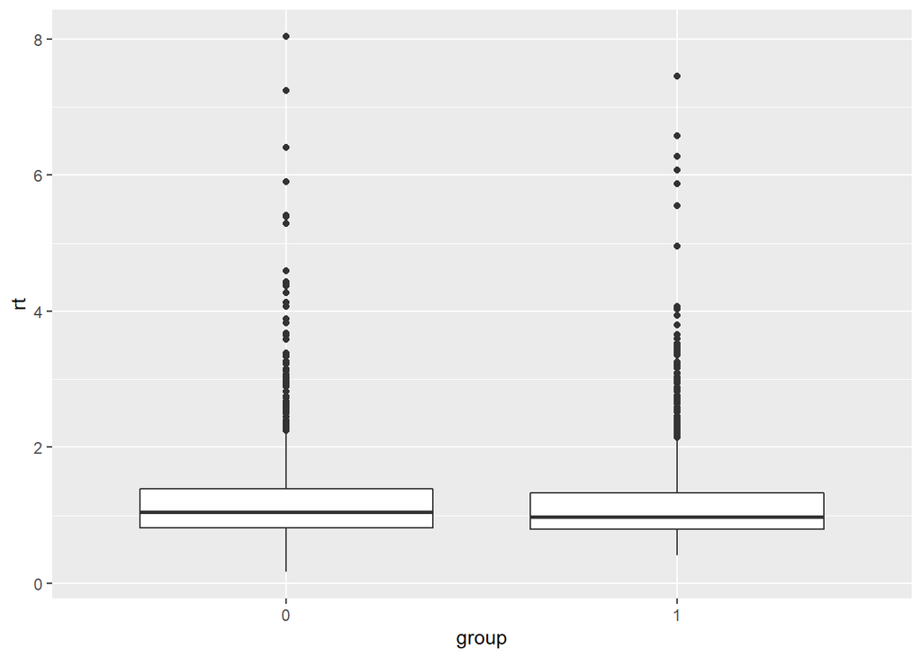

```r
ggplot(data, aes(y=rt, x=group)) +
  geom_boxplot()
```

### Barplots with errorbars

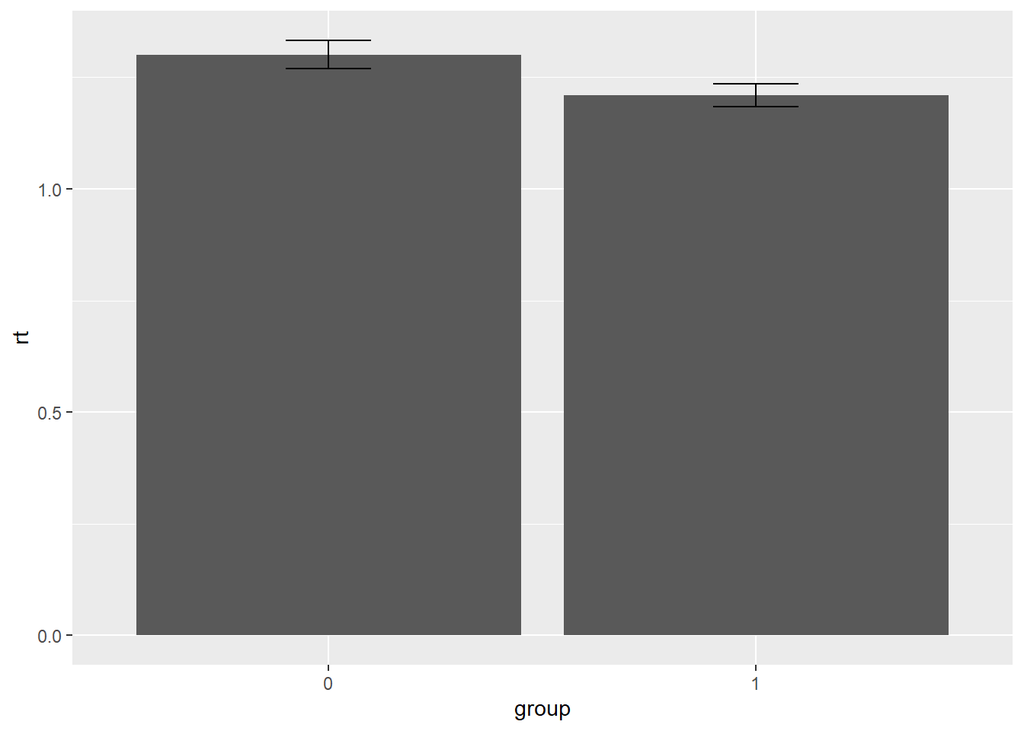

```r
ggplot(data, aes(y=rt, x=group)) +
  stat_summary(fun = "mean", geom = "bar", position = position_dodge()) +
  stat_summary(fun.data = "mean_se", geom = "errorbar", position = position_dodge(width = 0.4),
               width = 0.2)
```

# 4. Assumption checks

### Normality plot

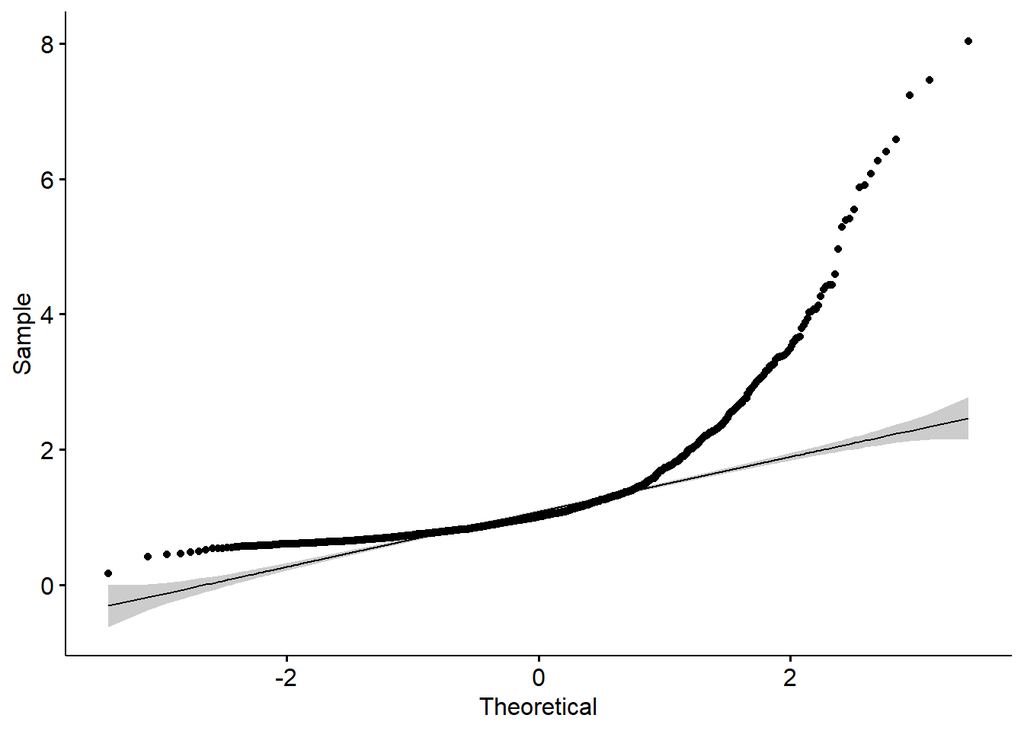

```r
ggpubr::ggqqplot(data$rt)
```

### Shaprio-Wilk test

```r
shapiro.test(data$rt)
```

```
##
##  Shapiro-Wilk normality test
##
## data:  data$rt
## W = 0.67426, p-value < 2.2e-16
```

### Homogeneity of variance tests

Bartlett’s test:

```r
bartlett.test(formula = rt ~ group, data = data)
```

```
##
##  Bartlett test of homogeneity of variances
##
## data:  rt by group
## Bartlett's K-squared = 8.1496, df = 1, p-value = 0.004307
```

Levene’s test:

```r
leveneTest(rt ~ group, data = data)
```

```
## Levene's Test for Homogeneity of Variance (center = median)
##         Df F value Pr(>F)
## group    1  1.7948 0.1805
##       1552
```

Bartlett’s is significant, while Levene’s is not. Possible reason is that Bartlett’s test is more sensitive to violation of normality; Levene’s is a bit more robust. See [here](https://stats.stackexchange.com/a/135235) for more information.

### Transformations

Before applying any transformations, we first need to check the skewness of the data as negative skew requires inversion. See [this tutorial](https://www.datanovia.com/en/lessons/transform-data-to-normal-distribution-in-r/#transformation-methods) for more information.

In this case the skewness of the data is 3.3244793.

Let’s now plot what different transformations do to the normality of our data.

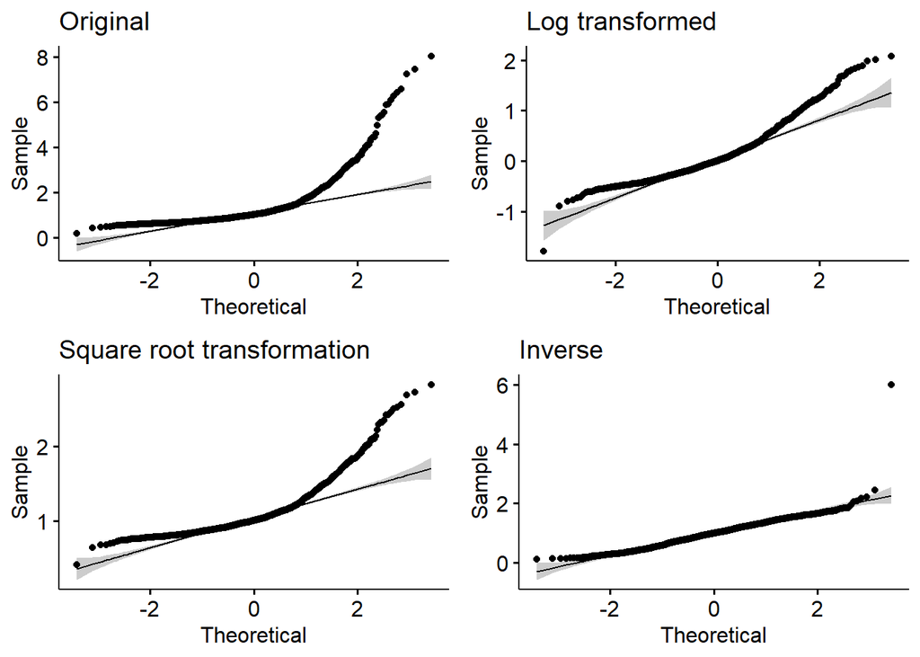

```r
plot1 <- ggqqplot(data$rt, title = "Original")
plot2 <- ggqqplot(log(data$rt), title = "Log transformed")
plot3 <- ggqqplot(sqrt(data$rt), title = "Square root transformation")
plot4 <- ggqqplot(1/data$rt, title = "Inverse")
grid.arrange(plot1, plot2, plot3, plot4, ncol=2)
```

The inverse transformations seems most appropriate from the graph above. To confirm, let’s use the Box-Cox procedure.

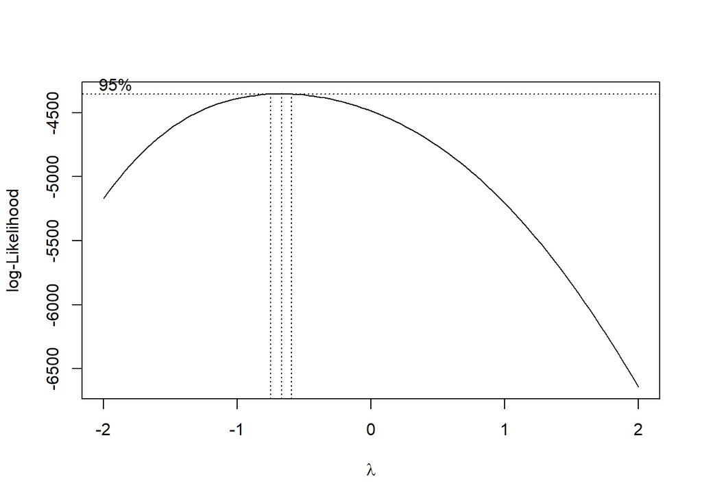

```r
lambdaList <- boxcox(rt~group, data=data)
```